# ZIP rozdelenie

## 3.4 Úloha: Graf pravdepodobnostnej a distribučnej funkcie Poisson a ZIP modelu

V druhej úlohe sme odhadli hodnotu parametrov. Použite tieto odhady a vytvorte grafy hustoty a distribučnej funkcie pre ZIP aj Poissonovo rozdelenie pre hodnoty $x = 0, 1, 2, 3, 4$ a $x ≥ 5$

### 3.4.1 Graf hustoty a distribučnej funkcie pre ZIP model

- odhady $ZIP(\lambda, p)$ sú $\hat{\lambda}$ = 0.2821 a $\hat{p}$ = 0.9015

**Graf hustoty pre ZIP rozdelenie**

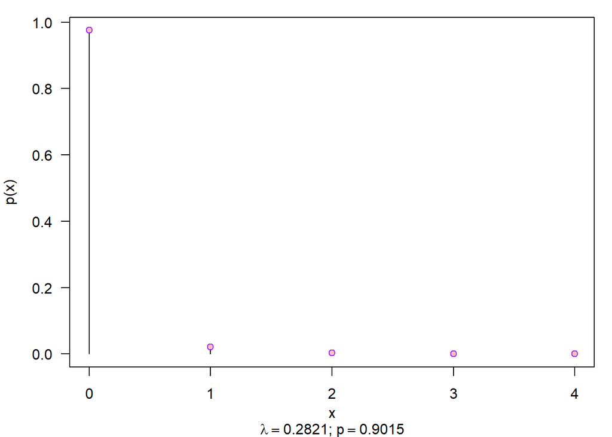

```r
#Vektor ocakavanych relativnych pocetnosti za predpokladu rozdelenia ZIP(lambda, p)
px_n <- VGAM::dzipois(0:4, lambda, p)

# graf funkcie hustoty
par(mar = c(4,4,1,1), mfrow = c(1, 1)) # nastavenie okrajov grafu (4, 4, 1, 1)
plot(n, px_n, type = 'h', ylab = 'p(x)', xlab = '', las = 1)
points(n, px_n, pch = 21, col = 'purple', bg = 'pink')
mtext('x', side = 1, line = 2.1)
mtext(bquote(paste(lambda == .(round(lambda, 4)), '; ', p == .(round(p,4)))), side = 1, line = 3.2)
```

**Graf distribučnej funkcie pre ZIP rozdelenie**

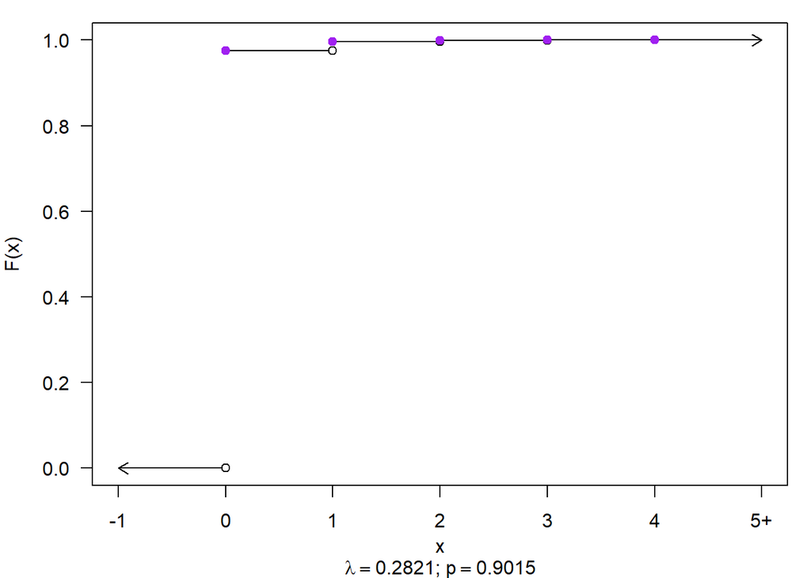

```r
# Vektor ocakavanych kumulativnch relativnych pocetnosti za predpokladu rozdelenia Pois(p, lambda)
Fx_n <- VGAM::pzipois(n, lambda, p)

# graf distribucnej funkcie
par(mar = c(4,4,1,1)) # nastavenie okrajov grafu (4, 4, 1, 1)
plot(n, Fx_n, type = 'n', xlim = c(-1,5), ylim = c(0, 1), xlab = '', ylab = 'F(x)', axes = F)
box(bty = 'o')
axis(1, -1:5, labels = c(-1:4, "5+"))
axis(2, las = 1)
segments(n, Fx_n, n + 1, Fx_n)
arrows(0, 0, -1, 0, length = 0.1)
arrows(4, 1, 5, 1, length = 0.1)

points(n, c(0, Fx_n[1:4]), col = 'black', pch = 21, bg = 'white')
points(n,Fx_n, col = 'purple', pch = 19)
mtext('x', side = 1, line = 2.1)
mtext(bquote(paste(lambda == .(round(lambda, 4)), '; ', p == .(round(p,4)))), side = 1, line = 3.2)
```

### 3.4.2 Graf hustoty a distribučnej funkcie pre Poissonov model

- odhady $Pois(\lambda)$ sú $\hat{\lambda_p}$ = 0.02779

**Graf hustoty pre Poissonovo rozdelenie**

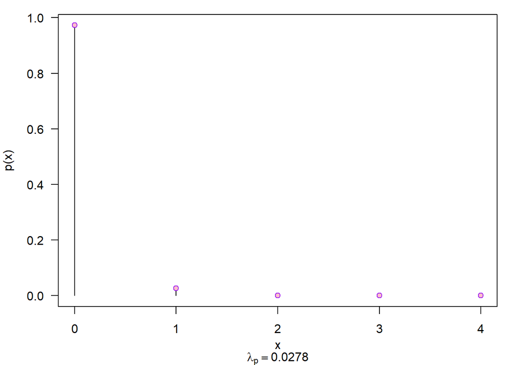

```r
# vektor ocakavanych relativnych pocetnosti za predpokladu rozdelenia Poisson(lambda_p)
px_n <- dpois(0:4,lambda_P)

### graf hustoty
par(mar = c(4,4,1,1), mfrow = c(1, 1)) # nastavenie okrajov grafu (4, 4, 1, 1)
plot(n, px_n, type = 'h', ylab = 'p(x)', xlab = '', las = 1)
points(n, px_n, pch = 21, col = 'purple', bg = 'pink')
mtext('x', side = 1, line = 2.1)
mtext(bquote(paste(lambda[p] == .(round(lambda_P, 4)))), side = 1, line = 3.2)
```

**Graf distribučnej funkcie pre Poissonovo rozdelenie**

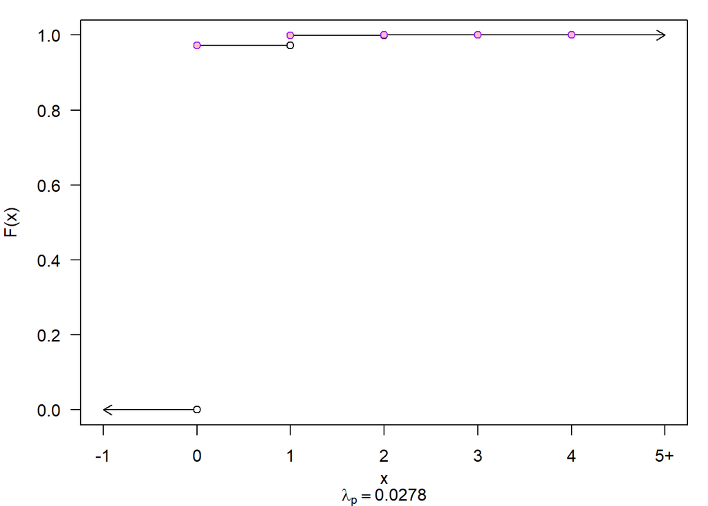

```r
# vektor ocakavanych kumulativnych relativnych pocetnosti za predpokladu rozdelenia NegBin(k, p)
Fx_n <- ppois(n, lambda_P)

### graf distribucnej funkcie
par(mar = c(4,4,1,1)) # nastavenie okrajov grafu (4, 4, 1, 1)
plot(n, Fx_n, type = 'n', xlim = c(-1,5), ylim = c(0, 1), xlab = '', ylab = 'F(x)', axes = F)
box(bty = 'o')
axis(1, -1:5, labels = c(-1:4, "5+"))
axis(2, las = 1)
segments(n, Fx_n, n + 1, Fx_n)
arrows(0, 0, -1, 0, length = 0.1)
arrows(4, 1, 5, 1, length = 0.1)

points(n, c(0, Fx_n[1:4]), col = 'black', pch = 21, bg = 'white')
points(n,Fx_n, pch = 21, col = 'purple', bg = 'pink')
mtext('x', side = 1, line = 2.1)
mtext(bquote(paste(lambda[p] == .(round(lambda_P, 4)))), side = 1, line = 3.2)
```

## 3.5 Úloha: Výpočet pravdepodobností na základe ZIP a Poissonovho modelu

Za predpokladu, že náhodná veličina $X$ , ktorá udáva počet primárnych a revíznych operácií, pochádza z ZIP rozdelenia, $X \sim ZIP(\lambda = 0.2821, p = 0.9015)$ alebo z Poissonovho rozdelenia $X \sim Pois(\lambda_p = 0.0278)$, vypočítajte pravdepodobnosť, že náhodne vybraný pacient podstúpil:

**iba primárnu operáciu**

```r
az <- VGAM::dzipois(0, lambda, p) |> format(digits = 5) # vypocet pravdepodobnosti (ZIP)
ap <- dpois(0, lambda_P) |> format(digits = 5) # vypocet pravdepodobnosti (Poiss)
paste('ZIP: ', az, '; Poisson: ', ap)
```

```
[1] "ZIP:  0.97578 ; Poisson:  0.97259"
```

**presne jednu revíznu operáciu**

```r
bz <- VGAM::dzipois(1, lambda, p) |> format(digits = 5) # vypocet pravdepodobnosti (ZIP)
bp <- dpois(1, lambda_P) |> format(digits = 5) # vypocet pravdepodobnosti (Poiss)
paste('ZIP: ', bz, '; Poisson: ', bp)
```

```
[1] "ZIP:  0.020961 ; Poisson:  0.027031"
```

**minimálne jednu a najviac dve revízne operácie**

```r
cz <- sum(VGAM::dzipois(1:2, lambda, p)) |> format(digits = 5) # vypocet pravdepodobnosti (ZIP)
cp <- sum(dpois(1:2, lambda_P)) |> format(digits = 5) # vypocet pravdepodobnosti (Poiss)
paste('ZIP: ', cz, '; Poisson: ', cp)
```

```
[1] "ZIP:  0.023918 ; Poisson:  0.027407"
```

**aspoň jednu revíznu operáciu**

```r
dz <- (1 - VGAM::dzipois(0, lambda, p)) |> format(digits = 5)  # vypocet pravdepodobnosti (ZIP)
dp <- (1 - dpois(0, lambda_P)) |> format(digits = 5) # vypocet pravdepodobnosti (Poiss)
paste('ZIP: ', dz, '; Poisson: ', dp)
```

```
[1] "ZIP:  0.024217 ; Poisson:  0.02741"
```

**najviac dve revízne operácie**

```r
ez <- sum(VGAM::dzipois(0:2, lambda, p)) |> format(digits = 5) # vypocet pravdepodobnosti (ZIP)
ep <- sum(dpois(0:2, lambda_P)) |> format(digits = 5) # vypocet pravdepodobnosti (Poiss)
paste('ZIP: ', ez, '; Poisson: ', ep)
```

```
[1] "ZIP:  0.9997 ; Poisson:  1"
```

**Porovnanie pravdepodobností**

```r
tab <- data.frame(rbind(c(az, bz, cz, dz, ez), c(ap, bp, cp, dp, ep)),
                        row.names = c('ZIP', 'Poisson'))
names(tab) = c('len_primarna', 'práve_1_revízna', '1_až_2_revízne', 'aspoň_1_revízna', 'najviac_2_revízne')
tab
```

```
        len_primarna práve_1_revízna 1_až_2_revízne aspoň_1_revízna
ZIP          0.97578        0.020961       0.023918        0.024217
Poisson      0.97259        0.027031       0.027407         0.02741
        najviac_2_revízne
ZIP                0.9997
Poisson                 1
```

Tabuľka 4: Porovnanie pravdepodobností pre Poisson a ZIP

| operácia | len primárna | práve 1 revízna | 1 až 2 revízne | aspoň 1 revízna | najviac 2 revízne |
| --- | --- | --- | --- | --- | --- |
| $ZIP$ | 0.97578 | 0.020961 | 0.023918 | 0.024217 | 0.9997 |
| $Poiss$ | 0.97259 | 0.027031 | 0.027407 | 0.027410 | 1 |

## 3.6 Úloha: Stredná hodnota a rozptyl náhodnej veličiny zo ZIP modelu

Za predpokladu, že náhodná veličina , ktorá udáva počet primárnych a revíznych operácií, pochádza zo ZIP rozdelenia, t.j. $X \sim ZIP(\lambda = 0.2821, p = 0.9015)$ vypočítajte strednú hodnotu $E[X]$ a rozptyl $Var[X]$ tejto náhodnej veličiny $X$. Strednú hodnotu a rozptyl porovnajte s ich odhadmi vypočítanými na:

- základe očakávaných početností,
- základe pozorovaných početností.

```r
## vektor ocakavanych abs. pocetnosti je v m_exp_zip
## vektor pozorovanych abs. pocetnosti je v observed

### Vypocet cez vzorce
E_X <- (1-p)*lambda # stredna hodnota E[X] rozdelenia ZIP(lambda, p) = (1-p)*lambda
Var_X <- (1-p)*lambda*(1+p*lambda) # rozptyl Var[X] rozdelenia ZIP(lambda, p) = (1-p)*lambda*(1+p*lambda)

### Vypocet na zaklade pozorovanych dat
observed <- rep(n, m_obs) # vektor pozorozovanych dat
E_obs <- mean(observed) # odhad strednej hodnoty na zaklade pozorozovanych dat.
Var_obs <- var(observed) # odhad rozptylu na zaklade pozorovanych dat

### Vypocet na zaklade odhadnutych dat
expected_zip <- rep(n, m_exp_zip) # vektor ocakavanych dat ZIP(lambda, p)
E_exp_z <- mean(expected_zip) # odhad strednej hodnoty na zaklade ocakakavanych dat ZIP(lambda, p)
Var_exp_z <- var(expected_zip)  # odhad rozptylu na zaklade ocakavanych dat ZIP(lambda, p)
(tab <- round(data.frame(E_X, E_obs, E_exp_z, Var_X, Var_obs, Var_exp_z), 4)) # sumarizacna tabulka vysledkov
```

```
     E_X  E_obs E_exp_z  Var_X Var_obs Var_exp_z
1 0.0278 0.0278  0.0278 0.0349  0.0349    0.0349
```

| E[X] - vzorec | E[X] observed | E[X] expected | Var[X] - vzorec | Var[X] observed | Var[X] expected |
| --- | --- | --- | --- | --- | --- |
| 0.0278 | 0.0278 | 0.0278 | 0.0349 | 0.0349 | 0.0349 |

Výsledky porovnajte s odhadmi vypočítanými za predpokladu Poissonovho modelu, kde $\lambda_p = 0.0278$

```r
expected_p <- rep(n, m_exp_pois) # vektor ocakavanych dat (Poiss)
E_exp_p <- mean(expected_p) # odhad strednej hodnoty na zaklade ocakavanych dat (Poiss)
Var_exp_p <- var(expected_p) # odhad rozptylu na zaklade ocakavanych dat (Poiss)
tab <- round(data.frame(rbind(E_obs, E_exp_z, E_exp_p),
                  rbind(Var_obs, Var_exp_z, Var_exp_p),
                  row.names = c('pozorované dáta', 'očakávané dáta: ZIP', 'očakávané dáta: Poiss')
                  ), 4)
names(tab) <- c('E(X)', 'Var(X)')
tab
```

```
                        E(X) Var(X)
pozorované dáta       0.0278 0.0349
očakávané dáta: ZIP   0.0278 0.0349
očakávané dáta: Poiss 0.0278 0.0278
```

## 3.7 Úloha: Simulačná štúdia pre ZIP model a Poissonov model

Pomocou simulačnej štúdie preskúmajte správanie náhodnej veličiny $X$, ktorá popisuje počet primárnych a revíznych operácií bedrového kĺbu u náhodne vybraného pacienta. Vygenerujte náhodný výber o rozsahu $M = 42 349$, ktorý pochádza zo ZIP rozdelenia s parametrami $\lambda = 0.2821$ a $p = 0.9015$. Vykreslite histogram tohto náhodného výberu a superponujte ho:

- 1. očakávanými početnosťami za predpokladu ZIP modelu s parametrami a odhadnutými z náhodného výberu,
- 2. očakávanými početnosťami za predpokladu Poissonovho modelu s parametrom odhadnutým tiež z náhodného výberu. Hodnoty očakávaných početností a pozorovaných početností navzájom porovnajte

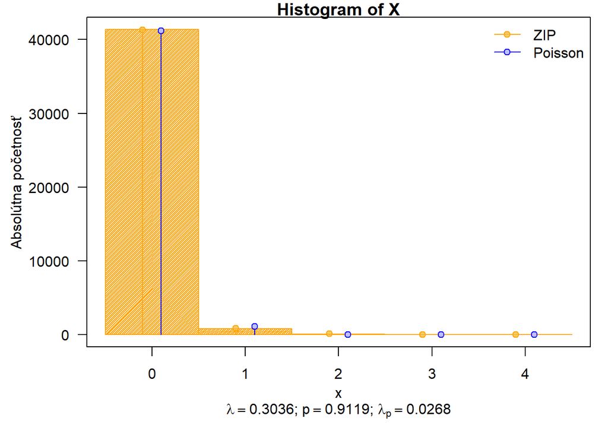

```r
M <- 42349 # celkovy pocet operacii M
X <- VGAM::rzipois(1:M, lambda, p) # vektor M pseudonahodnych cisel z rozdelenia ZIP(lambda, p)
N <- max(X) # maximalne vygenerovane cislo
m <- mean(X) # odhad strednej hodnoty E[X] ziskany z vektoru pseudonahodnych cisel
v <- var(X) # odhad rozptylu Var[X] ziskany z vektoru pseudonahodnych cisel

### Odhad parametrov
lambda_p <- m # odhad parametra lambda_p (Poiss) z vektoru pseudonahodnych cisel
lambda_z <- m + v/m - 1 # odhad parametra lambda (ZIP) z vektoru pseudonahodnych cisel
p <- (v - m)/(m^2 + v - m) # odhad parametra p (ZIP) z vektoru pseudonahodnych cisel

### Vypocet absolutnych pocetnosti
m_exp_z <- round(VGAM::dzipois(0:N, lambda_z, p)*M) # absolutne ocakavane pocetnosti (ZIP)
m_exp_p <- round(dpois(0:N, lambda_p)*M) # absolutne ocakavane pocetnosti (Poiss)

par(mar = c(5, 5, 1, 1)) # okraje grafu 5, 5, 1, 1
hist(X, breaks = seq(-0.5, N + 0.5, by = 1), prob = F, col = 'orange', density = 60, las = 1, xlab = '', ylab = '')
# histogram nahodneho vyberu v absolutnej skale
box(bty = 'o') # ramcek okolo grafu
x <- 0:(length(m_exp_z) - 1) # pomocny vektor
lines(x - 0.1, m_exp_zip, type = 'h', col = 'orange') # vertikalne ciary ocakavanych absolutnych pocetnosti (ZIP)
lines(x + 0.1, m_exp_pois, type = 'h', col = 'blue' ) # vertikalne ciary ocakavanych absolutnych pocetnost (Poiss)
points(x - 0.1, m_exp_zip, pch = 21, col = 'orange', bg = rgb(0.95,0.75,0.25,0.8)) # oranzovo-zlte body
points(x + 0.1, m_exp_pois, pch = 21, col = 'blue', bg = rgb(0.75,0.75,1,1)) # modre body
mtext('x', side = 1, line = 2.1) # popis osy x
mtext(bquote(paste(lambda == .(round(lambda_z, 4)), "; ",
                   p == .(round(p,4)), "; ",
                   lambda[p] == .(round(lambda_p, 4)))),
      side = 1, line = 3.3) # druhy popis osy
mtext('Absolútna početnosť', side = 2, line = 3.6) # popis osy y
legend('topright',
       lty = 1, #ciarocky
       pch = 21, # kruznice
       col = c('orange', 'blue'),
       pt.bg = c(rgb(0.95,0.75,0.25,0.8), rgb(0.75,0.75,1,1)),
       legend = c('ZIP', 'Poisson'),
       bty = 'n') # legenda
```